## The Model

### Model Overview

This is a simple SIR model with births and deaths and 2 types of direct transmission, density-dependent and frequency-dependent (based on the terminology in (Begon et al. 2002) - see *Further Information* tab for references).

This model has the following compartments:

- **S** - uninfected and susceptible individuals
- **I** - individuals who are infected and infectious.
- **R** - recovered/removed individuals.

The processes being modeled are:

- Susceptible individuals can become infected by two types of direct transmission from infected hosts, further described below.
- Infected hosts recover after some time (specified by the rate *g*).
- Recovered individuals are initially immune to reinfection. They can lose their immunity at rate *w* and return to the susceptible compartment.
- New susceptibles enter (are born) at a rate *m*. From each compartment, hosts “leave” after some time (i.e. they die) at rate *n*. The inverse of this rate is the average lifespan of a host.

The force of infection, denoted by *f* here, depends on the transmission model. For density-dependent transmission, it is given by *f = b<sub>d</sub> I / A*, where *A* is the area of the scenario under consideration (e.g. a city). For frequency-dependent transmission, we have *f = b<sub>f</sub> I / N*, where *N* is the size of the population, *N=S+I+R*.

### Model Implementation

The flow diagram and the set of ordinary differential equations (ODE) which are used to implement this model are as follows:

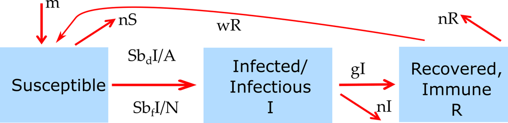

Flow diagram for this model.

$$\dot S =m - f S + wR - nS$$
$$\dot I = f S - g I -nI$$
$$\dot R = g I - wR - nR$$

with *f = b<sub>d</sub> I / A* for density-dependent transmission and *f = b<sub>f</sub> I / N* for frequency-dependent transmission.

### Model Comments

Note that quite often, we assume that the area is constant and do not include it in the model or even talk about it. Often, the population size is also assumed to be constant. In that case, the 2 types of transmission models behave the same. But as soon as area or population size change, the model results differ. You can explore the effect of this relationship using this simulation.